# Assignment_2_통계학과 김상현

## 과제 2: Python 기반 CNN 구조의 이해 및 결과 제출

통계학과 석과과정 김상현(202682114)

```python
import torch
from  torch import nn, optim
from torchvision import datasets, transforms
import matplotlib.pyplot as plt

# mac os에선 mps 사용
DEVICE = "mps" if torch.mps.is_available() else "cpu"
```

이번 과제에선 MINST 데이터를 이용하여 총 3개의 모델을 만들어 비교해보겠다.

1. 교재 14쪽 SIMPLE CNN
2. LeNet5
3. MLP

```python
from torch import nn

class SIMPLE_CNN(nn.Module):
    def __init__(self):
        super().__init__()
        self.conv1 = nn.Sequential(
            nn.Conv2d(1, 3, kernel_size=5),   # (28,28,1) -> (24,24,3)
            nn.SiLU(),                         # swish = SiLU
            nn.MaxPool2d(2),                   # -> (12,12,3)
            nn.Conv2d(3, 6, kernel_size=5),    # -> (8,8,6)
            nn.SiLU(),
            nn.MaxPool2d(2),                   # -> (4,4,6)
        )
        self.fc1 = nn.Sequential(
            nn.Flatten(),                      # -> 4*4*6 = 96, FC layer을 통과하기 위함.
            nn.Linear(4 * 4 * 6, 84),
            nn.SiLU(),
            nn.Linear(84, 10),
        )

    def forward(self, x):
        x = self.conv1(x)
        x = self.fc1(x)
        return x
```

```python
from torchsummary import summary

model = SIMPLE_CNN()

summary(model, input_size=(1, 28, 28))
```

```
----------------------------------------------------------------
        Layer (type)               Output Shape         Param #
================================================================
            Conv2d-1            [-1, 3, 24, 24]              78
              SiLU-2            [-1, 3, 24, 24]               0
         MaxPool2d-3            [-1, 3, 12, 12]               0
            Conv2d-4              [-1, 6, 8, 8]             456
              SiLU-5              [-1, 6, 8, 8]               0
         MaxPool2d-6              [-1, 6, 4, 4]               0
           Flatten-7                   [-1, 96]               0
            Linear-8                   [-1, 84]           8,148
              SiLU-9                   [-1, 84]               0
           Linear-10                   [-1, 10]             850
================================================================
Total params: 9,532
Trainable params: 9,532
Non-trainable params: 0
----------------------------------------------------------------
Input size (MB): 0.00
Forward/backward pass size (MB): 0.04
Params size (MB): 0.04
Estimated Total Size (MB): 0.08
----------------------------------------------------------------
```

```python
from torch import nn

class LeNet_5(nn.Module):
    def __init__(self):
        super().__init__()

        self.conv1 = nn.Sequential(nn.Conv2d(1, 6, 5, stride=1, padding=2), # 논문에선 32x32짜리의 데이터를 예시로 했음
                                   nn.SiLU()) #swish                        # 우리가 사용하는 MNIST는 28x28이므로 zero-padding 2 추가!

        self.Maxpool1 = nn.MaxPool2d(2, 2)

        self.conv2 = nn.Sequential(nn.Conv2d(6, 16, 5),
                                   nn.SiLU())

        self.Maxpool2 = nn.MaxPool2d(2, 2)

        self.fc = nn.Sequential(nn.Linear(16 * 5 * 5, 120),
                                nn.SiLU(),
                                nn.Linear(120, 84),
                                nn.SiLU(),
                                nn.Linear(84, 10))

    def forward(self, x):
        x = self.conv1(x)
        x = self.Maxpool1(x)
        x = self.conv2(x)
        x = self.Maxpool2(x)
        x = torch.flatten(x, start_dim=1)
        x = self.fc(x)
        return x
```

LeNet5를 구현하기 위해 한 가지 중요한 점이 있다.

우선 논문에서 아키텍처를 구현할때 사용한 데이터는 32x32 데이터이다.

하지만 우리가 쓰는 MNIST 데이터는 아래에서 언급하겠지만 28x28 데이터이다.

따라서 논문과 같은 셋팅을 위해선 첫 Conv layer에 zero-padding 2를 추가하여 shape을 맞춰줄 필요가 있다.

위의 코드를 보면

```
self.conv1 = nn.Sequential(nn.Conv2d(1, 6, 5, stride = 1, padding = 2))
```

를 보면 알 수 있다.

여기서 zero-padding은 **how to pad the input volume with zeros around the border** 이다.

input data의 경계에 0의 값은 가진 값을 둘러주는 것이다.

이런식으로 zero-padding은 사이즈를 맞춰주는 역할도 있지만

다음과 같은 상황을 방지하기 위해서 많이 사용된다.

Consider a 32X32 input convolved repeadly with 5X5 filters... then volume will shrinks spatially (32->28->24...)

Shrinking too fast -> not good --> 이게 왜 안좋을걸까? --> input(output) shrink fast --> layer 수 적어임 --> 깊은 network 생성 불가능 --> 일반화 bad

```python
from torchsummary import summary

model = LeNet_5()

summary(model, input_size=(1, 28, 28))
```

```
----------------------------------------------------------------
        Layer (type)               Output Shape         Param #
================================================================
            Conv2d-1            [-1, 6, 28, 28]             156
              SiLU-2            [-1, 6, 28, 28]               0
         MaxPool2d-3            [-1, 6, 14, 14]               0
            Conv2d-4           [-1, 16, 10, 10]           2,416
              SiLU-5           [-1, 16, 10, 10]               0
         MaxPool2d-6             [-1, 16, 5, 5]               0
            Linear-7                  [-1, 120]          48,120
              SiLU-8                  [-1, 120]               0
            Linear-9                   [-1, 84]          10,164
             SiLU-10                   [-1, 84]               0
           Linear-11                   [-1, 10]             850
================================================================
Total params: 61,706
Trainable params: 61,706
Non-trainable params: 0
----------------------------------------------------------------
Input size (MB): 0.00
Forward/backward pass size (MB): 0.11
Params size (MB): 0.24
Estimated Total Size (MB): 0.35
----------------------------------------------------------------
```

### 1. Train 함수 생성

```python
def Train(model, train_DL, val_DL, criteron, optimizer, EPOCH):
    loss_history = []
    acc_history = []
    val_loss_history = []
    val_acc_history = []
    NoT = len(train_DL.dataset)
    NoV = len(val_DL.dataset)

    for ep in range(EPOCH):
        # model을 훈련모드로 전환 --> dropout, BatchNorm 등 훈련과 test에서 작용 방식이 다른 놈들을 위한
        model.train()
        rloss = 0
        rcorrect = 0
        for x_batch, y_batch in train_DL:
            x_batch = x_batch.to(DEVICE)
            y_batch = y_batch.to(DEVICE)
            # inference
            y_hat = model(x_batch)
            # loss
            loss = criteron(y_hat, y_batch)
            # update
            optimizer.zero_grad() # 각 epoch마다 gradient 누적방지
            # backprop
            loss.backward()
            # weight update
            optimizer.step()
            # loss accum
            loss_b = loss.item() * x_batch.shape[0]
            rloss += loss_b
            # accuracy accum
            pred = y_hat.argmax(dim = 1)
            correct_b = torch.sum(pred == y_batch).item()
            rcorrect += correct_b

        loss_e = rloss / NoT
        loss_history += [loss_e]
        accuracy_e = rcorrect / NoT * 100
        acc_history += [accuracy_e]

        # Vali
        model.eval()
        val_rloss = 0
        val_rcorrect = 0
        with torch.no_grad():
            for x_batch, y_batch in val_DL:
                x_batch = x_batch.to(DEVICE)
                y_batch = y_batch.to(DEVICE)
                # inference
                y_hat = model(x_batch)
                # loss
                val_loss = criteron(y_hat, y_batch)
                # loss accum
                val_loss_b = val_loss.item() * x_batch.shape[0]
                val_rloss += val_loss_b
                # accuracy accum
                pred = y_hat.argmax(dim = 1)
                correct_b = torch.sum(pred == y_batch).item()
                val_rcorrect += correct_b

        val_loss_e = val_rloss / NoV
        val_loss_history += [val_loss_e]
        val_accuracy_e = val_rcorrect / NoV * 100
        val_acc_history += [val_accuracy_e]

        print(f"Epoch: {ep+1}, train loss: {round(loss_e, 3)}, val loss: {round(val_loss_e, 3)}")
        print(f"Train Accuracy: {rcorrect}/{NoT} ({round(accuracy_e, 1)}%)")
        print(f"Val Accuracy: {val_rcorrect}/{NoV} ({round(val_accuracy_e, 1)}%)")
        print("-"*20)

    return loss_history, acc_history, val_loss_history, val_acc_history
```

#### `y_hat.argmax(dim = 1)`

예를 들어서 사진 X을 모델에 통과해서 4종류의 동물을 구분하는 분류 문제를 푼다고 하자.

데이터가 모델을 통과 -> logit -> softmax(다중분류) -> 확률이 나올것이다.

```
y_hat =
[[0.1, 0.7, 0.05, 0.15],   # 샘플 0
 [0.6, 0.1, 0.2,  0.1 ],   # 샘플 1
 [0.2, 0.1, 0.6,  0.1 ]]   # 샘플 2
```

위와 같이 확률 값이 output으로 나올거다.

우선 샘플0만을 보면

```
  개   고양이  사슴   말
[[0.1, 0.7, 0.05, 0.15]]
```

이라고 생각하면 쉽다.

그럼 샘플0 즉 첫번째 사진 X_0는 확률이 제일 높은 0.7 고양이 사진이라고 모델이 판단하게 되는것이다.

단순히 y_hat의 정보를 위의 matrix로 보는것보다.

`argmax(dim=1)`을 사용해서 각 행에서 가장 큰 값의 인덱스를 반환하게 하자.

```
pred = y_hat.argmax(dim=1)

pred = [1, 0, 2] ==> 이런식으로 각 샘플에서 가장 큰 값의 인덱스를 받을 수 있다.
```

이제 이를

```
torch.sum(pred == y_batch).item()
```

y_batch와 비교하여 sum을 하면 모델이 맞춘 정답의 수를 알 수 있다.

### 2. Test 함수 생성

```python
def Test(model, test_DL):
    #test 모드로 전환
    model.eval()

    with torch.no_grad():
        rcorrect = 0
        for x_batch, y_batch in test_DL:
            x_batch = x_batch.to(DEVICE)
            y_batch = y_batch.to(DEVICE)

            #inference
            y_hat = model(x_batch)
            pred = y_hat.argmax(dim = 1)
            correct_b = torch.sum(pred == y_batch).item()
            rcorrect += correct_b
        accuracy_e = rcorrect / len(test_DL.dataset) * 100
    print(f"Test Accuaracy: {rcorrect}/{len(test_DL.dataset)} ({round(accuracy_e, 1)}%)")
```

### 3. Model에서 예측한 사진 VS 실제 사진 비교하는 함수

```python
def Test_plot(model, test_DL):
    model.eval()
    with torch.no_grad():
        x_batch, y_batch = next(iter(test_DL))
        x_batch = x_batch.to(DEVICE)
        y_hat = model(x_batch)
        pred = y_hat.argmax(dim=1)

    x_batch = x_batch.to("cpu")

    plt.figure(figsize=(8,4))
    for idx in range(6):
        plt.subplot(2,3, idx+1, xticks=[], yticks=[])
        plt.imshow(x_batch[idx].permute(1,2,0).squeeze(), cmap="gray")
        pred_class = test_DL.dataset.classes[pred[idx]]
        true_class = test_DL.dataset.classes[y_batch[idx]]
        plt.title(f"{pred_class} ({true_class})", color = "g" if pred_class==true_class else "r")
```

### 4. Data load

```python
transform = transforms.ToTensor()
train_DS = datasets.MNIST(root = '/Volumes/김상현/dataset', train = True, download = False, transform = transform)
test_DS = datasets.MNIST(root = '/Volumes/김상현/dataset', train = False, download = False, transform = transform)
print("Data load completed")
```

```
Data load completed
```

```python
print(f"Information of train dataset {train_DS}")
print(f"Information of test dataset {test_DS}")
```

```
Information of train dataset Dataset MNIST
    Number of datapoints: 60000
    Root location: /Volumes/김상현/dataset
    Split: Train
    StandardTransform
Transform: ToTensor()
Information of test dataset Dataset MNIST
    Number of datapoints: 10000
    Root location: /Volumes/김상현/dataset
    Split: Test
    StandardTransform
Transform: ToTensor()
```

```python
print(f"Train dataset classes(target)")
train_DS.classes
```

```
Train dataset classes(target)
```

```
['0 - zero',
 '1 - one',
 '2 - two',
 '3 - three',
 '4 - four',
 '5 - five',
 '6 - six',
 '7 - seven',
 '8 - eight',
 '9 - nine']
```

```python
train_DS.class_to_idx
```

```
{'0 - zero': 0,
 '1 - one': 1,
 '2 - two': 2,
 '3 - three': 3,
 '4 - four': 4,
 '5 - five': 5,
 '6 - six': 6,
 '7 - seven': 7,
 '8 - eight': 8,
 '9 - nine': 9}
```

아까 argmax(dim=1) 부분을 다시 떠올려보면

```
y_hat = [0.1, 0.05, 0.7, 0.02, ...]
         ↑     ↑     ↑
       idx=0  idx=1  idx=2  ...

이미지 '2' 입력
    ↓
모델 출력: [0.05, 0.03, 0.88, 0.01, ...]
                          ↑
                        idx=2 가 제일 크다!
    ↓
argmax → pred = 2
    ↓
class_to_idx에서 '2 - two': 2 와 매칭 → 정답!
```

이는 torchvision의 `ImageFolder` 클래스에 구현되어있음 --> 나중에 custom dataset 만들때 주의하자.

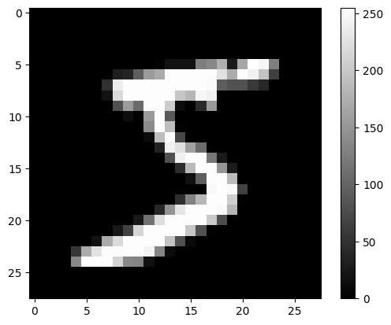

```python
plt.imshow(train_DS.data[0], cmap="gray")
plt.colorbar()
plt.show()
```

```python
print(train_DS.data[0].shape)
```

```
torch.Size([28, 28])
```

#### 주의!!

논문에서 구현된 아키텍처는 32 x 32 데이터를 기준으로 했지만

우리가 사용할 MINST 데이터는 28 x 28 데이터이다..!

따라서 첫 번째 layer에서 `zero-padding = 2`를 추가해줘야한다.

```python
print(train_DS.targets)
print(train_DS.targets.shape)
```

```
tensor([5, 0, 4,  ..., 5, 6, 8])
torch.Size([60000])
```

다음은 본격적으로 학습을 위해 각종 hyperparameter를 정해주고 데이터 모델을 만들어보겠다.

### 1. DataLoader & Set hyper-parameters

```python
BATCH_SIZE = 32
LR = 1e-3
EPOCH = 10
criterion = nn.CrossEntropyLoss()
new_model_train = True
model_type = "SIMPLE_CNN"
dataset = "MNIST"
save_model_path = f'/Volumes/김상현/results/Multiclass_Classification_MNIST/{model_type}_{dataset}.pt'
```

```python
from torch.utils.data import random_split

train_DS, val_DS = random_split(train_DS, [50000, 10000])

# DataLoader ==> batch_size만큼 꺼내서 모델한테 가져다주는 역할해줌
train_DL = torch.utils.data.DataLoader(train_DS, batch_size=BATCH_SIZE, shuffle=True)
val_DL = torch.utils.data.DataLoader(val_DS, batch_size=BATCH_SIZE, shuffle=True)
test_DL = torch.utils.data.DataLoader(test_DS, batch_size=BATCH_SIZE, shuffle=True)
```

### 2. Train model

```python
model = SIMPLE_CNN().to(DEVICE)
```

```
Epoch: 1, train loss: 0.336, val loss: 0.141
Train Accuracy: 44773/50000 (89.5%)
Val Accuracy: 9603/10000 (96.0%)
--------------------
Epoch: 2, train loss: 0.111, val loss: 0.091
Train Accuracy: 48284/50000 (96.6%)
Val Accuracy: 9711/10000 (97.1%)
--------------------
Epoch: 3, train loss: 0.08, val loss: 0.075
Train Accuracy: 48718/50000 (97.4%)
Val Accuracy: 9766/10000 (97.7%)
--------------------
Epoch: 4, train loss: 0.064, val loss: 0.059
Train Accuracy: 49022/50000 (98.0%)
Val Accuracy: 9813/10000 (98.1%)
--------------------
Epoch: 5, train loss: 0.054, val loss: 0.056
Train Accuracy: 49165/50000 (98.3%)
Val Accuracy: 9813/10000 (98.1%)
--------------------
Epoch: 6, train loss: 0.048, val loss: 0.062
Train Accuracy: 49234/50000 (98.5%)
Val Accuracy: 9790/10000 (97.9%)
--------------------
Epoch: 7, train loss: 0.042, val loss: 0.059
Train Accuracy: 49301/50000 (98.6%)
Val Accuracy: 9818/10000 (98.2%)
--------------------
Epoch: 8, train loss: 0.037, val loss: 0.054
Train Accuracy: 49408/50000 (98.8%)
Val Accuracy: 9842/10000 (98.4%)
--------------------
Epoch: 9, train loss: 0.034, val loss: 0.06
Train Accuracy: 49422/50000 (98.8%)
Val Accuracy: 9810/10000 (98.1%)
--------------------
Epoch: 10, train loss: 0.03, val loss: 0.052
Train Accuracy: 49492/50000 (99.0%)
Val Accuracy: 9844/10000 (98.4%)
--------------------
```

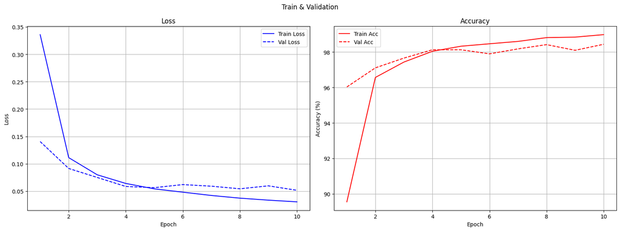

```python
if new_model_train:
    optimizer = optim.Adam(model.parameters(), lr = LR)
    loss_history, acc_history, val_loss_history, val_acc_history = Train(model, train_DL, val_DL, criterion, optimizer, EPOCH)

    torch.save(model, save_model_path)

    fig, (ax1, ax2) = plt.subplots(1, 2, figsize=(16, 6))

    # 왼쪽 그래프 - Loss
    ax1.plot(range(1, EPOCH + 1), loss_history, color='blue', label='Train Loss')
    ax1.plot(range(1, EPOCH + 1), val_loss_history, color='blue', linestyle='--', label='Val Loss')
    ax1.set_xlabel('Epoch')
    ax1.set_ylabel('Loss')
    ax1.set_title('Loss')
    ax1.legend()
    ax1.grid()

    # 오른쪽 그래프 - Accuracy
    ax2.plot(range(1, EPOCH + 1), acc_history, color='red', label='Train Acc')
    ax2.plot(range(1, EPOCH + 1), val_acc_history, color='red', linestyle='--', label='Val Acc')
    ax2.set_xlabel('Epoch')
    ax2.set_ylabel('Accuracy (%)')
    ax2.set_title('Accuracy')
    ax2.legend()
    ax2.grid()

    plt.suptitle('Train & Validation')
    plt.tight_layout()
    plt.show()
```

### 4. Test model

```python
load_model = torch.load(save_model_path, map_location = DEVICE, weights_only = False)
```

```python
Test(load_model, test_DL)
```

```
Test Accuaracy: 9861/10000 (98.6%)
```

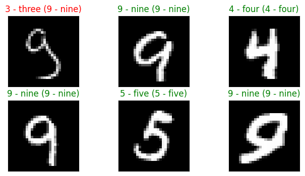

```python
Test_plot(load_model, test_DL)
```

3이라고 잘못 예측한 손글씨를 보면 다른 9와 다르게 3처럼 아래부분이 많이 휘어있어서 모델이 잘못 판단했을 가능성이 높아보인다.

### LeNet5

```python
model_type = "LeNet_5"
dataset = "MNIST"
save_model_path = f'/Volumes/김상현/results/Multiclass_Classification_MNIST/{model_type}_{dataset}.pt'
```

```python
model = LeNet_5().to(DEVICE)
```

```
Epoch: 1, train loss: 0.228, val loss: 0.088
Train Accuracy: 46385/50000 (92.8%)
Val Accuracy: 9741/10000 (97.4%)
--------------------
Epoch: 2, train loss: 0.063, val loss: 0.059
Train Accuracy: 49033/50000 (98.1%)
Val Accuracy: 9825/10000 (98.2%)
--------------------
Epoch: 3, train loss: 0.044, val loss: 0.047
Train Accuracy: 49297/50000 (98.6%)
Val Accuracy: 9852/10000 (98.5%)
--------------------
Epoch: 4, train loss: 0.032, val loss: 0.054
Train Accuracy: 49466/50000 (98.9%)
Val Accuracy: 9854/10000 (98.5%)
--------------------
Epoch: 5, train loss: 0.026, val loss: 0.042
Train Accuracy: 49580/50000 (99.2%)
Val Accuracy: 9889/10000 (98.9%)
--------------------
Epoch: 6, train loss: 0.021, val loss: 0.049
Train Accuracy: 49657/50000 (99.3%)
Val Accuracy: 9859/10000 (98.6%)
--------------------
Epoch: 7, train loss: 0.015, val loss: 0.052
Train Accuracy: 49746/50000 (99.5%)
Val Accuracy: 9879/10000 (98.8%)
--------------------
Epoch: 8, train loss: 0.015, val loss: 0.063
Train Accuracy: 49751/50000 (99.5%)
Val Accuracy: 9843/10000 (98.4%)
--------------------
Epoch: 9, train loss: 0.012, val loss: 0.059
Train Accuracy: 49818/50000 (99.6%)
Val Accuracy: 9855/10000 (98.6%)
--------------------
Epoch: 10, train loss: 0.011, val loss: 0.062
Train Accuracy: 49812/50000 (99.6%)
Val Accuracy: 9876/10000 (98.8%)
--------------------
```

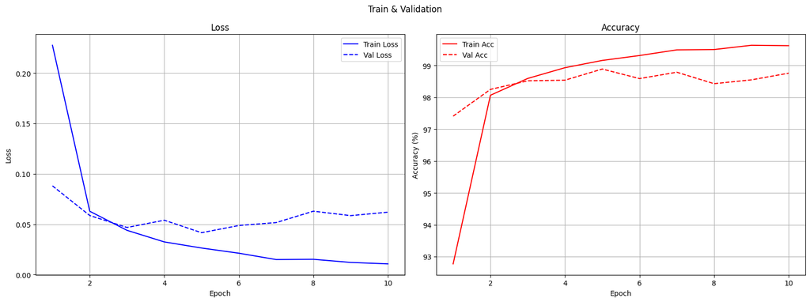

```python
if new_model_train:
    optimizer = optim.Adam(model.parameters(), lr = LR)
    loss_history, acc_history, val_loss_history, val_acc_history = Train(model, train_DL, val_DL, criterion, optimizer, EPOCH)

    torch.save(model, save_model_path)

    fig, (ax1, ax2) = plt.subplots(1, 2, figsize=(16, 6))

    # 왼쪽 그래프 - Loss
    ax1.plot(range(1, EPOCH + 1), loss_history, color='blue', label='Train Loss')
    ax1.plot(range(1, EPOCH + 1), val_loss_history, color='blue', linestyle='--', label='Val Loss')
    ax1.set_xlabel('Epoch')
    ax1.set_ylabel('Loss')
    ax1.set_title('Loss')
    ax1.legend()
    ax1.grid()

    # 오른쪽 그래프 - Accuracy
    ax2.plot(range(1, EPOCH + 1), acc_history, color='red', label='Train Acc')
    ax2.plot(range(1, EPOCH + 1), val_acc_history, color='red', linestyle='--', label='Val Acc')
    ax2.set_xlabel('Epoch')
    ax2.set_ylabel('Accuracy (%)')
    ax2.set_title('Accuracy')
    ax2.legend()
    ax2.grid()

    plt.suptitle('Train & Validation')
    plt.tight_layout()
    plt.show()
```

epoch 5 이후 과적합 보인다.

먼서 **overfitting**을 방지하는 법을 설명하기 전에 ML에서 우리가 싸워야할 가장 큰 두 적에 해서 말해보겠다.

1. **underfitting**

underfitting은 일반적으로 bias가 main error이다. 이는 모델을 훈련할때 다른 optimization 방법을 쓰면서 해결할 수 있다.

대표적으론 EWMA와 모멘텀을 이용한 Adam이 있다.

2. **overfitting**

overfitting은 일반적으로 variance가 main error이다. 이는 모델을 훈련할때 다른 **regularzation**을 이용하면 된다.

규제의 방법으론 model에 constraints를 추가, objective function에 extra terms을 추가 그리고 ensemble methdos를 이용하는 것이 있다.

DL에선 대표적으로 Early stopping, 일종의 bagged ensemble methods인 Dropout 등이 있다.

```python
load_model = torch.load(save_model_path, map_location = DEVICE, weights_only = False)
Test(load_model, test_DL)
```

```
Test Accuaracy: 9878/10000 (98.8%)
```

SIMPLE_CNN보다 0.2가량 test 성능이 높아졌다.

하지만 parameter 수가 많이 늘어난것에 비해 높은 상승은 아닌듯하다.

주어진 데이터, task에 맞는 적잘한 모델의 사용이 필요할듯하다.

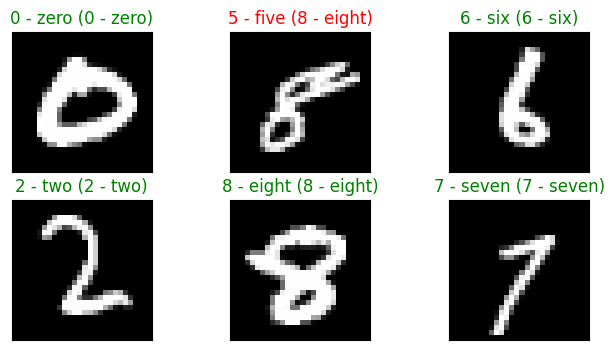

```python
Test_plot(load_model, test_DL)
```

### MLP

```python
model_type = "MLP"
dataset = "MNIST"
save_model_path = f'/Volumes/김상현/results/Multiclass_Classification_MNIST/{model_type}_{dataset}.pt'
```

```python
# SIMPLE MLP MODEL

from torch import nn

class MLP(nn.Module):
    def __init__(self):
        super().__init__()

        self.linear = nn.Sequential(nn.Linear(28 * 28, 80),
                                    nn.ReLU(),
                                    nn.Linear(80, 10))

    def forward(self, x):
        x = torch.flatten(x, start_dim=1)
        x = self.linear(x)
        return x
```

```python
from torchsummary import summary

model = MLP()

summary(model, input_size=(1, 28, 28)) # LeNet5와 파라메터수 비슷하게 맞춤
```

```
----------------------------------------------------------------
        Layer (type)               Output Shape         Param #
================================================================
            Linear-1                   [-1, 80]          62,800
              ReLU-2                   [-1, 80]               0
            Linear-3                   [-1, 10]             810
================================================================
Total params: 63,610
Trainable params: 63,610
Non-trainable params: 0
----------------------------------------------------------------
Input size (MB): 0.00
Forward/backward pass size (MB): 0.00
Params size (MB): 0.24
Estimated Total Size (MB): 0.25
----------------------------------------------------------------
```

```
Epoch: 1, train loss: 0.36, val loss: 0.231
Train Accuracy: 45026/50000 (90.1%)
Val Accuracy: 9339/10000 (93.4%)
--------------------
Epoch: 2, train loss: 0.177, val loss: 0.16
Train Accuracy: 47446/50000 (94.9%)
Val Accuracy: 9535/10000 (95.3%)
--------------------
Epoch: 3, train loss: 0.123, val loss: 0.126
Train Accuracy: 48172/50000 (96.3%)
Val Accuracy: 9619/10000 (96.2%)
--------------------
Epoch: 4, train loss: 0.094, val loss: 0.111
Train Accuracy: 48603/50000 (97.2%)
Val Accuracy: 9673/10000 (96.7%)
--------------------
Epoch: 5, train loss: 0.074, val loss: 0.109
Train Accuracy: 48895/50000 (97.8%)
Val Accuracy: 9647/10000 (96.5%)
--------------------
Epoch: 6, train loss: 0.062, val loss: 0.1
Train Accuracy: 49103/50000 (98.2%)
Val Accuracy: 9688/10000 (96.9%)
--------------------
Epoch: 7, train loss: 0.05, val loss: 0.101
Train Accuracy: 49240/50000 (98.5%)
Val Accuracy: 9706/10000 (97.1%)
--------------------
Epoch: 8, train loss: 0.041, val loss: 0.1
Train Accuracy: 49383/50000 (98.8%)
Val Accuracy: 9703/10000 (97.0%)
--------------------
Epoch: 9, train loss: 0.036, val loss: 0.098
Train Accuracy: 49475/50000 (99.0%)
Val Accuracy: 9719/10000 (97.2%)
--------------------
Epoch: 10, train loss: 0.03, val loss: 0.109
Train Accuracy: 49558/50000 (99.1%)
Val Accuracy: 9677/10000 (96.8%)
--------------------
```

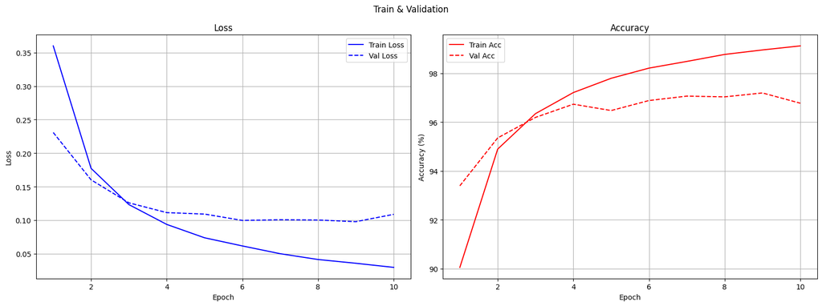

```python
model = MLP().to(DEVICE)

if new_model_train:
    optimizer = optim.Adam(model.parameters(), lr = LR)
    loss_history, acc_history, val_loss_history, val_acc_history = Train(model, train_DL, val_DL, criterion, optimizer, EPOCH)

    torch.save(model, save_model_path)

    fig, (ax1, ax2) = plt.subplots(1, 2, figsize=(16, 6))

    # 왼쪽 그래프 - Loss
    ax1.plot(range(1, EPOCH + 1), loss_history, color='blue', label='Train Loss')
    ax1.plot(range(1, EPOCH + 1), val_loss_history, color='blue', linestyle='--', label='Val Loss')
    ax1.set_xlabel('Epoch')
    ax1.set_ylabel('Loss')
    ax1.set_title('Loss')
    ax1.legend()
    ax1.grid()

    # 오른쪽 그래프 - Accuracy
    ax2.plot(range(1, EPOCH + 1), acc_history, color='red', label='Train Acc')
    ax2.plot(range(1, EPOCH + 1), val_acc_history, color='red', linestyle='--', label='Val Acc')
    ax2.set_xlabel('Epoch')
    ax2.set_ylabel('Accuracy (%)')
    ax2.set_title('Accuracy')
    ax2.legend()
    ax2.grid()

    plt.suptitle('Train & Validation')
    plt.tight_layout()
    plt.show()
```

```python
load_model = torch.load(save_model_path, map_location = DEVICE, weights_only = False)

# Test MLP model simailar # of parameter with LeNet5
Test(load_model, test_DL)
```

```
Test Accuaracy: 9709/10000 (97.1%)
```

SIMPLE_CNN, LeNet5, MLP 3가지 모델 중에 MLP 모델이 test 성능이 가장 낮게 나왔다.

그 이유는 무엇일까?

바로 알 수 있는 부분을 MLP는 image을 모델에 입력하기 위해서 데이터를 flatten한다 --> 공간적 정보 완전히 사라짐.

그리고 MLP와 다르게 CNN은 Local connectivity와 Parameter Sharing이라는 큰 특징이 있다.

이는 MLP에서 모든 뉴런이 전 layer의 뉴런에 fully connected 되어 있는거와 다르게,

spatial하게 only a local region(filter size) of the input volume

따라서 input image의 특징을 좀 더 잘 잡을 수 있다.

sharing parameters across differnet part of a model -> IN CNN : same kernel across image regions

즉 동일한 weight를 가진 Kernel input data를 슬라이딩하면서 본다.

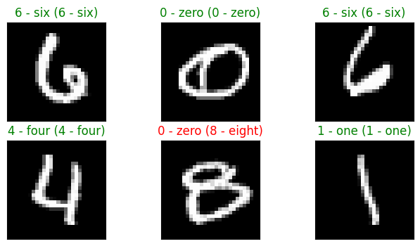

```python
Test_plot(load_model, test_DL)
```